# Comparison w/o salt

Anne-Karin Cooke

# Important changes

## Constants

Soil properties were derived from standard Australian soils in Neurotheta (Minasny and McBratney, 2002, as cited in Shah et al, 2011).

```r
R= 0.0821 # gas constant [ L atm mol-1 K-1 ]
Temp= 298 # temperature in Kelvin,  25 degrees Celsius
Mm= 58.44 # molar mass of NaCl in g/mol


# SOIL INPUT - medium heavy Clay
# n<-0.4473
# s_fc<-0.3936/n # Field capacity
# Hydraulic conductivity
# K_s<-2.82*10 # mm/day

#Z =614.25
Z =100 # cm GROUNDWATER DEPTH

#Coarse Sand

# Campbell's b
  b= 4.1152

n = 0.368 # porosity
  s_fc = 0.1895/n # Field capacity
# Hydraulic conductivity
  K_s = 182.68*10 # cm/day to mm/day

  psi_s_bar = -0.61E-3
  h1bar =  -psi_s_bar
  hb = psi_s_bar*-10^4
  Ep=10

soilpar <- list(b = b, n = n, s_fc = s_fc, K_s = K_s,
                psi_s_bar = psi_s_bar, h1bar = h1bar, hb = hb, Ep=Ep)
    #................................................
    # Vegetation 1 (Grass)
    # paspalum secateum F-I and R-I, 2004
    # Gives only parameters
    #.................................................
    Zr = 40 # soil depth (cm)   Also Table 2...Fernandez-Illescas and Rodriguez-Iturbe...2001
    c_p=0.4
vegpar <- list(Zr = Zr, c_p=c_p)
```

## Infiltration function

```r
Infil <- function(h,P, alpha_i=0.25, k=12, W0=0.2){

  I=alpha_i*h*(P+k*W0)/(P+k)

  return (I)
}
```

## Water uptake function

```r
par_in <- list(gmax=0.05, k1=5)
WU <- function(M,P,par=par_in){
# using Svir in here means scaling Svir back to M, easier to do at Svir in balances
#  WU=par$gmax*((M*(1+Svir))/(((M*(1+Svir))+par$k1)))*P
  WU=par$gmax*(M/((M+par$k1)))*P

  return(WU)
}
```

## Plant growth function

```r
par_in$c=10

Gr <- function(M,P,par=par_in) {

  Gr = par$c*WU(M,P,par)

  return(Gr)
}
```

## Plant mortality function

```r
Mo <- function(P,M,Svir,d=0.1) {
  # needs to be M/Svir because both are "large" numbers
  # you want a number ~1 for multiplication, or <0.1 for addition
  Mo = P*(d*(M/Svir))

  return(Mo)
}
```

## G function (Eagelson 1978)

```r
G <- function(b,hb,Z) {
  b1 <- 2+3/b
  a1 <- 1+(3/2)/(b1-1)
  H1 <- a1*(hb/Z)^b1
  return(H1)
}
# test
G(b=soilpar$b,hb=soilpar$hb, Z=Z)
```

```
## [1] 0.0009045487
```

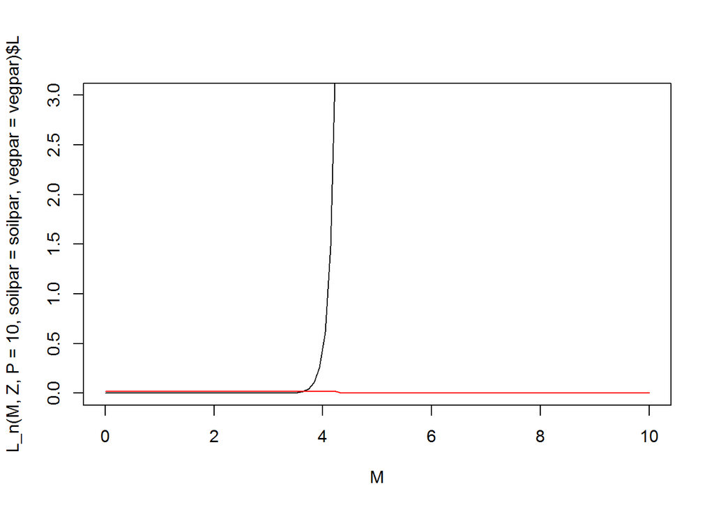

```r
#******************************************
L_n <- function(M,Z,P,soilpar,vegpar) {
   Zr <- vegpar$Zr
   hb <- soilpar$psi_s_bar*-10^4
   #browser()
   soilpar$s_fc <- (Z/hb)^(-1/soilpar$b)


  s=M/(soilpar$n*Zr)

  # capillary upflow
  G1 <- G(soilpar$b,hb,Z) # using the G function
  u_set <- s[s < soilpar$s_fc]


    # UpT=G1*K_s*(1-exp(-c*P))*Ep


  u <- c(rep(G1*soilpar$K_s*(1-exp(-(vegpar$c_p*P)))*soilpar$Ep,length(u_set)),rep(0,(length(M)-length(u_set))))
   # u <- c(rep(G1*K_s,length(u_set)),rep(0,(length(M)-length(u_set))))
  # leaching
  #ifelse(soilpar$s_fc>n,soilpar$s_fc<-soilpar$s_fc,soilpar$s_fc<-n)
  l <- M*exp(-((soilpar$s_fc-M/(Zr*soilpar$n))*K_s/(Zr*soilpar$n)))

return(list(U=u,L=l))
}

# test
 M <- seq(0,10,length=100)
 Z <- 1000
plot(M,L_n(M,Z,P=10,soilpar=soilpar,vegpar=vegpar)$L,type="l",ylim=c(0,3))
lines(M,L_n(M,Z,P=2,soilpar=soilpar,vegpar=vegpar)$U,col="red")
```

## Leaching function

```r
# L <- function(M,K_s,s_fc,Zr_in=Zr,n_1=n) {
#
#   L=M*exp(-((s_fc-M/(Zr_in*n_1))*K_s/(Zr_in*n_1)))
#
#   return(L)
# }
```

## Soil moisture and salt balance

```r
 balances <- function(Rain, par=par_in,plotit=F,
                      soilpar,
                      vegpar,
                      f= 0.4, ConcConst = 0.1,  CM.gw = 5){

   # f is the soil salt leaching efficiency (whether some salt is retained)
   # ConcConst is the concentration of the salt in the infiltrating water
   # Storage vectors


# Storage vectors for the daily steps are initialized.


   M <- rep(0,length(Rain)) # soil moisture [mm]
   h <- rep(0,length(Rain)) # infiltration depth [mm]
   P <- rep(0,length(Rain)) #biomass density []
   CM<- rep(0,length(Rain)) # Salt concentration in soil water in g/L or g/mm
   SmI<- rep(0,length(Rain)) # Salt mass in infiltrating water [g]
   SmM <- rep(0,length(Rain)) # Salt mass in soil water [g]
   In <- rep(0,length(Rain)) # infiltration [mm]
# Leach <- rep(0,length(Rain)) # leaching [mm]
   Svir <- rep(0,length(Rain)) # virtual saturation

   L<- rep(0,length(Rain))
   U<- rep(0,length(Rain))


# Initial values to start the simulation.


   M[1] <- 3
   h[1] <- 10
   P[1] <- 3
   CM[1]<- 0
   Svir[1] <- M[1]


# We decided to split the numerical calculations for the daily into 12 substeps.

   deltat <- 12 # split in 12 increments


# Storage vectors for the substeps are initialized.

   M_sub <- rep(0,deltat)
   h_sub <- rep(0,deltat)
   I_sub <- rep(0,deltat)
   #Q_sub <- rep(0,deltat)
   WU_sub <-rep(0,deltat) # Water uptake in mm
   P_sub <- rep(0,deltat)
   Gr_sub <- rep(0,deltat) # Growth of biomass
   Mo_sub<- rep(0,deltat) # Mortality of biomass
   SmI_sub <- rep(0,deltat)
   SmM_sub<- rep(0,deltat)
   CM_sub<- rep(0,deltat)
   # Posm_bar<- rep(0,deltat) # osmotic pressure of soil water in bar
   # fosm<- rep(0,deltat) # "osmotic factor", reduces available soil water to plant water uptake
   L_sub <- rep(0,deltat) # leaching
  Svir_sub <- rep(0,deltat) # virtual saturation

   L_sub<-rep(0,deltat) # calculates leakage loss without evaporation loss
   U_sub<-rep(0,deltat)


   timeincr= 1/deltat

  for (t in 2:length(Rain)){

    for (tt in 1:(deltat-1)) {

      h.old <- ifelse(tt==1,h[t-1],h_sub[tt])
      P.old <- ifelse(tt==1,P[t-1],P_sub[tt])
      M.old <- ifelse(tt==1,M[t-1],M_sub[tt])
      SmI.old <-ifelse(tt==1,SmI[t-1],SmI_sub[tt])
      CM.old <-ifelse(tt==1,CM[t-1],CM_sub[tt])
     Svir.old <-ifelse(tt==1,Svir[t-1],Svir_sub[tt])

# The impact of the the osmotic pressure is calculated using Van't Hoff's law. For that, molarity is calculated dividing the
# concentration by the molar mass of NaCl (58.44 g/mol). The osmotic pressure is the product of molarity, universal gas constant and temperature in Kelvin.
# The wilting point is found at an pressure of -15 bar.
# Between 0 and 15 bar, an "osmotic factor", scaled from 1 to 0, is added to the Water uptake function. At fosm = 0, not water uptake by plants is possoble.
#       Posm_bar[tt]= ((CM.old/Mm)*R*Temp)*1.01325
#       ifelse(Posm_bar[tt]<=15,fosm[tt] <- 1-(Posm_bar[tt]/15), fosm[tt] <- 0)    #fosm, osmotic factor

# Balance for water depth on soil

      h_sub[tt+1] <- h.old + ifelse(tt==1,Rain[t],0) - Infil(h.old, P.old)*timeincr

# Infiltration

      I_sub[tt] <- Infil(h.old, P.old)*timeincr

#  1. Update soil moisture with infiltration

      M_sub[tt + 1] <- M.old + I_sub[tt]

# Now do all plant uptake and growth
# water uptake by plants: include infiltration in available water

       #M_sub[tt + 1] <- M_sub[tt] + Svir_sub[tt]

      WU_sub[tt] <- WU(M=Svir.old,P.old,par)*timeincr

      # growth rate
      Gr_sub[tt] <- Gr(M=Svir.old, P.old,par)*timeincr
      # Mortality
      Mo_sub[tt]<- Mo(P.old, M=M.old, Svir=Svir.old, d=par_in$d)*timeincr
      # calculate plant biomass balance
      P_sub[tt + 1] <- P.old + Gr_sub[tt]- Mo_sub[tt]


# re-calculate water balance
# 2. before leaching
      M_sub[tt + 1] <- M.old + I_sub[tt] - WU_sub[tt] #- L_sub[tt]

# Calculate salt concentration in the soil
      CM_sub[tt+1]<- SmM_sub[tt+1]/M_sub[tt + 1]
#browser()
      # 3. calculate leaching amount
#       L_sub[tt] <- L(M_sub[tt+1], soilpar$K_s, soilpar$s_fc,soilpar$Zr,soilpar$n)*timeincr
#    L_sub[tt] <- L_n(M=M_sub[tt],Z=Z,soilpar=soilpar,vegpar=vegpar)$L
   L_sub[tt]<-do.call(L_n,list(M = M_sub[tt + 1], P = P_sub[tt + 1], Z = Z,
                               soilpar = soilpar,vegpar = vegpar))$L

   U_sub[tt]<-do.call(L_n,list(M = M_sub[tt + 1],P = P_sub[tt + 1], Z = Z,
                               soilpar = soilpar, vegpar = vegpar))$U
   # U_sub[tt]<-do.call(L_n,list(M=M_sub[tt + 1],Z=Z,soilpar=soilpar,vegpar=vegpar))$U
      # 4. final adjust soil moisture for leaching
       M_sub[tt + 1] <- M_sub[tt + 1] - L_sub[tt]*timeincr + U_sub[tt]*timeincr

# calculate saltbalance
    L_salt <- CM.old*L_sub[tt]*timeincr
    U_salt <- CM.gw*U_sub[tt]*timeincr

      SmI_sub[tt+1]<- SmI.old + I_sub[tt]*ConcConst - L_salt
      SmM_sub[tt+1]<- SmI_sub[tt + 1]

#       SmGW_sub[tt+1] <- SmGW.old + L_salt - U_salt


#browser()
    # I have now scaled Svir to M
    Svir_sub[tt + 1]<-soilpar$n*vegpar$Zr*((soilpar$h1bar)^(1/soilpar$b))*
                     ((soilpar$h1bar)*(M_sub[tt + 1]/
                       (soilpar$n*vegpar$Zr))^(-soilpar$b)
                       +(3.6*CM_sub[tt + 1]))^(-1/soilpar$b)

    }

# Aggregating the substep results to daily values.

    P[t] = P_sub[deltat]
    M[t] = M_sub[deltat]
    h[t] = h_sub[deltat]
    CM[t] = CM_sub[deltat]
    SmM[t] = SmI[t] = SmM_sub[deltat]
    In[t]= I_sub[deltat]
    L[t] = L_sub[deltat]
    U[t] = U_sub[deltat]
    Svir[t] = Svir_sub[deltat]

}


# Plotting

if (plotit==T) {
  plot(M, type="l",ylim=c(0,100),xlim=c(0,time),xlab=("time [d]"), main="with salt") # main=paste("lambda=", lambda[j],"alpha=", alpha[i]))
  points(Rain*10, type="h", col="skyblue")

    lines(Svir,type="l", col="blue")
    abline(h=0, col="Gray50",lwd=2,lty=2)

    lines(SmM,type="l", col="red")
    lines(CM,type="l", col="purple")
    lines(P,type="l", col="green")


#  legend("topright",cex=1, pt.cex=0.4, c("Moisture [mm]","Rainfall [mm]*10","overland flow depth[mm] ","salt mass in soil water [g]", "salt concentration in soil water [g/l]", "Plant biomass density [g/m^2]"),
#           col=c("black","skyblue","blue","red","purple","green"),lty=1)
#

}

Out <- data.frame(P=P,M=M,h=h, CM=CM, SmM=SmM, In=In, L=L, U=U, Svir=Svir)
return(Out)
}
```

source the Moisture function script source(“MoistureFunction.R”) source(“Rainfall.R”)

## Rainfall function

```r
Precip <- function(time,alpha,lambda,delta) {
  # generate a vector of times between rainfall events > delta
  f_P<-floor(rexp(time,lambda*exp(-delta/alpha))) # vector of times between rainfall occurrences (equation 4 & 8)
  # generate a binary vector from this (impulse function)
  binary.vec <- unlist(lapply(1:time,function(i) c(rep(0,f_P[i]),1)))
  R <- rexp(length(binary.vec),1/alpha)*binary.vec
  return(R[1:time])
}
```

The generated rainfall is stored in a list to be used in further experiments.

```r
# for (i in 1:length(alpha)) {
#   for (j in 1:length(lambda)) {
# Rainlist[[i]][[j]] <- list(Rain <- Precip(time,alpha[i],lambda[j],delta))
#     }
#   }
```

## Changing climates

Alpha and lambda are set as sequence of 10 different value.

```r
alpha <- seq(0.6,1.5,by=0.1)
lambda <- seq(0.1,1,by=0.1)

Store <- list()
sub_store <- list()
time <- 1000
delta <- 0
set.seed(1000)
```

This loop generates rainfall with the distribution properties alpha[i] and lambda[j]. For each alpha[i] and each lambda[j] the soil water balance function is executed and the results stored in a nested list.

```r
# set the mortality value
par_in$d <- 0.05

for (i in 1:length(alpha)) {

for (j in 1:length(lambda)) {
    # generate the rainfall
    Rain <- Precip(time,alpha[i],lambda[j],delta)
    Rainlist <- data.frame(Precip(time,alpha[i],lambda[j],delta))

    sub_store[[j]] <-data.frame(alpha_o=rep(alpha[i],time),
                                lambda_o=rep(lambda[j],time),
                                balances(Rain,plotit=F, par=par_in,
                                soilpar=list(n=n, s_fc=s_fc,
                                             K_s=K_s, psi_s_bar=psi_s_bar,
                                             h1bar=h1bar, b=b, Ep=Ep),
                                             vegpar=list(Zr=40, c_p=0.4)))
  }
  Store[[i]] <- sub_store
}
```

## Results

### Plotted climate combinations

clim1: lambda=0.1, alpha=0.6 clim2: lambda=1, alpha=0.6 clim3: lambda=0.5, alpha=1 clim4: lambda=0.1, alpha=1.5 clim5: lambda=1, alpha=1.5

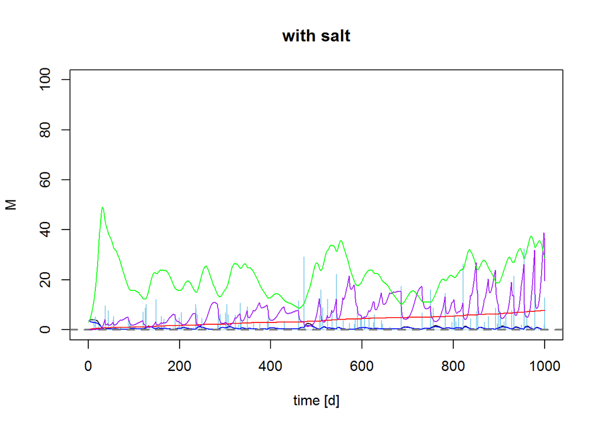

```r
#with salt

clim1rain <- Precip(time,alpha=0.6,lambda=0.1,delta)
clim1 <- balances(Rain=clim1rain,plotit=T, soilpar=list(n=n,Zr=Zr, s_fc=s_fc,
                                             K_s=K_s, psi_s_bar=psi_s_bar,
                                             h1bar=h1bar, b=b, Ep=Ep),
                                             vegpar=list(c_p=0.4,Zr=Zr))
```

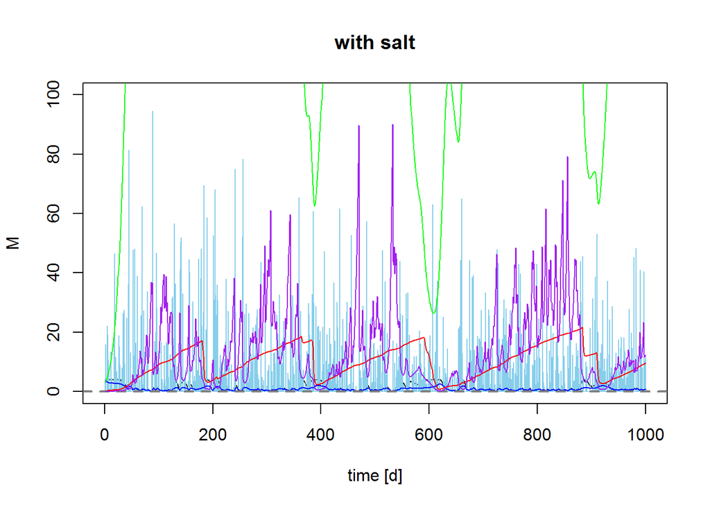

```r
# #without salt
#
# # clim1 <- balances_woSalt(Rain=clim1rain,plotit=T, soilpar=list(K_s=K_s,n=n,Zr=Zr,s_fc=s_fc))
#
# # clim2rain <- Precip(time,alpha=0.6,lambda=1,delta)
# # clim2 <- balances(Rain=clim2rain,plotit=T, soilpar=list(K_s=K_s,n=n,Zr=Zr,s_fc=s_fc))
# # clim3rain <- Precip(time,alpha=1,lambda=0.5,delta)
# # clim3 <- balances(Rain=clim3rain,plotit=T, soilpar=list(K_s=K_s,n=n,Zr=Zr,s_fc=s_fc))
# # clim4rain <- Precip(time,alpha=1.5,lambda=0.1,delta)
# # clim4 <- balances(Rain=clim4rain,plotit=T, soilpar=list(K_s=K_s,n=n,Zr=Zr,s_fc=s_fc))
#
# #with salt
 clim5rain <- Precip(time,alpha=1.5,lambda=1,delta)
# clim5 <- balances(Rain=clim5rain,plotit=T, soilpar=list(K_s=K_s,n=n,Zr=Zr,s_fc=s_fc))
#
# without salt
clim5 <- balances(Rain=clim5rain,plotit=T, soilpar=list(n=n,Zr=Zr, s_fc=s_fc,
                                             K_s=K_s, psi_s_bar=psi_s_bar,
                                             h1bar=h1bar, b=b, Ep=Ep),
                                             vegpar=list(c_p=0.4,Zr=Zr))
```

Plotting M and P for different lambdas

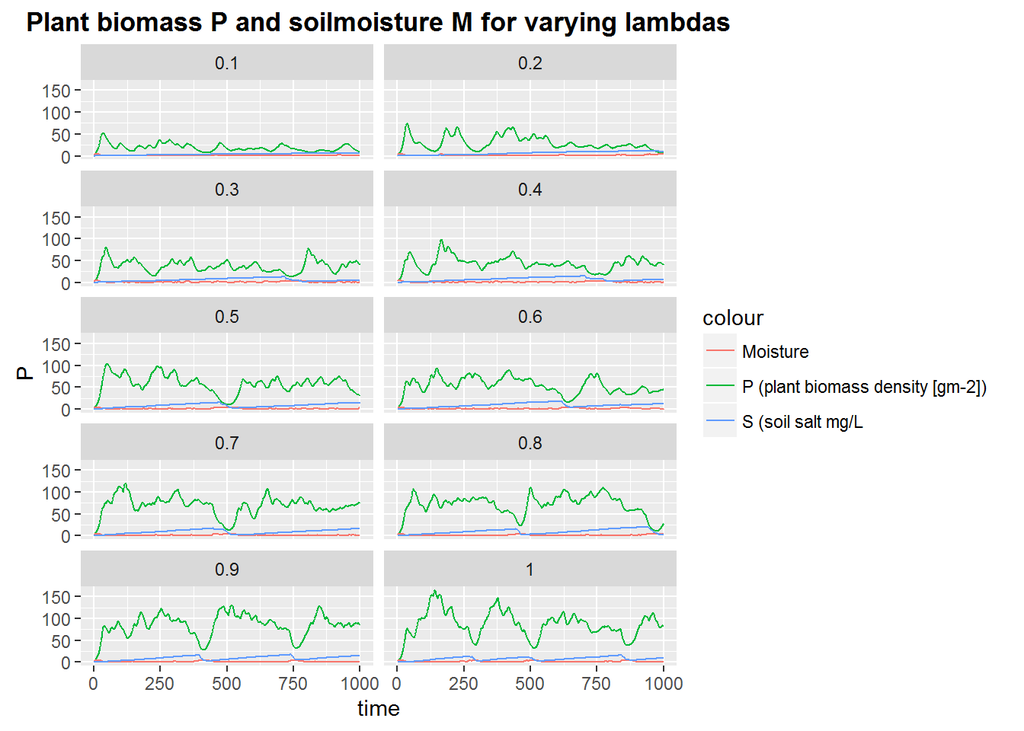

```r
require(ggplot2)
lambda_sum <- do.call(rbind,Store[][[2]])
lambda_sum$time <- rep(1:time,length(lambda))

pl <- ggplot(lambda_sum,aes(x=time,y=P, colour="P (plant biomass density [gm-2])")) + geom_line()
pl  <- pl + geom_line(aes(x=time,y=M, colour="Moisture"))
pl <- pl +  facet_wrap(~lambda_o, ncol=2)   #, colour=lambda_o (put this in aes-brackets)
pl  + ggtitle("Plant biomass P and soilmoisture M for varying lambdas") +  geom_line(aes(x=time, y=SmM, colour= "S (soil salt mg/L")) + theme(plot.title = element_text(lineheight=.8, face="bold"))
```

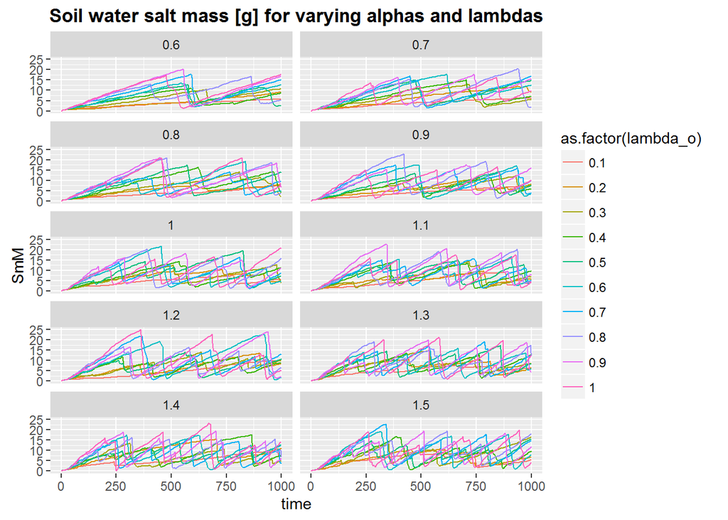

```r
lambda_sum_all <- do.call(rbind,do.call(rbind,Store))
lambda_sum_all$time <- rep(rep(1:time,length(lambda)),length(alpha))


pa <- ggplot(lambda_sum_all,aes(x=time,y=SmM,col=as.factor(lambda_o))) + geom_line(linetype=1)
# pa <- pa + + scale_color_gradient(low="blue", high="red")
pa <- pa  + facet_wrap(~alpha_o, ncol=2) + ggtitle("Soil water salt mass [g] for varying alphas and lambdas") + theme(plot.title = element_text(lineheight=.8, face="bold"))
pa
```

# Comparing results

```r
# Biomass without salt
# summary(lambda_sum_woSalt$P)
# Biomass with salt
summary(lambda_sum$P)
```

```
##    Min. 1st Qu.  Median    Mean 3rd Qu.    Max.
##    3.00   31.02   53.40   55.39   76.78  165.40
```

```r
#Soil moisture without salt
# summary(lambda_sum_woSalt$M)
#Soil moisture with salt
summary(lambda_sum$M)
```

```
##    Min. 1st Qu.  Median    Mean 3rd Qu.    Max.
## 0.08432 0.42820 0.69990 1.12300 1.28500 4.01900
```

```r
summary(lambda_sum$Svir)
```

```
##    Min. 1st Qu.  Median    Mean 3rd Qu.    Max.
## 0.08432 0.42310 0.66370 0.79090 1.01500 3.82700
```

```r
# summary(1+lambda_sum$Svir)
# summary(-lambda_sum$Svir*n*Zr)
```